# BANA4137 DataCamp Homework Sequence

Yichen Qin (qinyn@ucmail.uc.edu)

# Instructions

Go to DataCamp website:

https://www.datacamp.com/groups/shared_links/326ad702e1a24481a4e11df1ddd25421ff077b6f7526ae0a094a1cdf90965b9d

Register an account with DataCamp using your UC email “username@mail.uc.edu”. Note that your account will be given free access to all the courses **only if you register using UC email address using the link above**. Once the registration is done, please remember your account username and password. We will use this account to do all homework this semester.

For homework submission, please submit the screen shots which show that you have finished these sections to Canvas by the deadline. To take a screen shot, press “PrtSc” (or Shift + PrtSc or Alt + PrtSc depending on your system), paste it to the Paint application and save it as an image file. Here is an example.

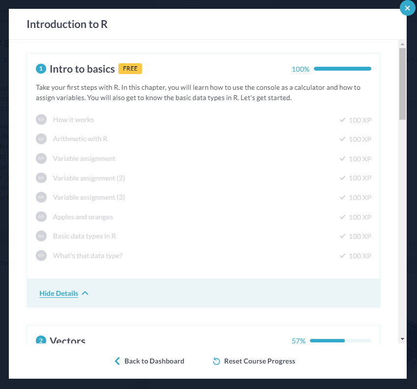

For grading, points are evenly distributed among all sections.

# Homework 1 (See Canvas for due date)

Complete the course “Introduction to R” at (https://app.datacamp.com/learn/courses/free-introduction-to-r). For this homework, please **finish the first three sections**.

# Homework 2 (See Canvas for due date)

Complete the course “Introduction to R” at (https://app.datacamp.com/learn/courses/free-introduction-to-r). For this homework, please **finish the last three sections**.

# Homework 3 (See Canvas for due date)

Complete the course “Introduction to the Tidyverse” (https://app.datacamp.com/learn/courses/introduction-to-the-tidyverse). For this homework, please **finish the first two sections**.

# Homework 4 (See Canvas for due date)

Complete the course “Introduction to the Tidyverse” (https://app.datacamp.com/learn/courses/introduction-to-the-tidyverse). For this homework, please **finish the last two sections**.

# Homework 5 (See Canvas for due date)

Complete the course “Reporting with R Markdown” at (https://app.datacamp.com/learn/courses/reporting-with-rmarkdown). For this homework, please finish **only the first three sections**.

# Homework 6 (See Canvas for due date)

Complete the course “Introduction to Data Visualization with ggplot2” at (https://app.datacamp.com/learn/courses/introduction-to-data-visualization-with-ggplot2). For this homework, please **finish only the first two sections**.

# Homework 7 (See Canvas for due date)

Complete the course “Introduction to Data Visualization with ggplot2” at (https://app.datacamp.com/learn/courses/introduction-to-data-visualization-with-ggplot2). For this homework, please **finish the last two sections**.

# Homework 8 (See Canvas for due date)

Complete the course “Introduction to Tableau” at (https://app.datacamp.com/learn/courses/introduction-to-tableau). For this homework, please **finish only the first two sections**.

# Homework 9 (See Canvas for due date)

Complete the course “Introduction to Tableau” at (https://app.datacamp.com/learn/courses/introduction-to-tableau). For this homework, please **finish the last two sections**.

# Homework 10 (See Canvas for due date)

Complete the course “Introduction to Power BI” at (https://app.datacamp.com/learn/courses/introduction-to-power-bi). For this homework, please **finish only the first two sections**.

# Homework 11 (See Canvas for due date)

Complete the course “Introduction to Power BI” at (https://app.datacamp.com/learn/courses/introduction-to-power-bi). For this homework, please **finish the last two sections**.